# Psych 254 W15 PS #3

Mike Frank

February 22, 2015

This is problem set #3, in which we want you to integrate your knowledge of data wrangling with some basic simulation skills and some linear modeling.

```r
library(dplyr)
```

```r
library(tidyr)
library(ggplot2)
library(lme4)
```

# Part 1: Basic simulation and NHST

Let’s start by convincing ourselves that t-tests have the appropriate false positive rate. Run 10,000 t-tests with standard, normally-distributed data from a made up 30-person, single-measurement experiment (the command for sampling from a normal distribution is `rnorm`). What’s the mean number of “significant” results?

First do this using a `for` loop.

```r
d = data.frame()
p = data.frame()
sig_res = data.frame()

# for(i in 1:10000) {
#   d = rnorm(30)
#   p[,"pval"] = pnorm(d)
#   sig_res[i] = p %>%
#     filter(x < 0.05)
# }
```

Next, do this using the `replicate` function:

Ok, that was a bit boring. Let’s try something moderately more interesting - let’s implement a p-value sniffing simulation, in the style of Simons, Nelson, & Simonsohn (2011).

Consider this scenario: you have done an experiment, again with 30 participants (one observation each, just for simplicity). The question is whether their performance is above chance. You aren’t going to check the p-value every trial, but let’s say you run 30 - then if the p-value is within the range p < .25 and p > .05, you optionally run 30 more and add those data, then test again. But if the original p value is < .05, you call it a day, and if the original is > .25, you also stop.

First, write a function that implements this sampling regime.

```r
double.sample <- function () {
}
```

Now call this function 10k times and find out what happens.

Is there an inflation of false positives? How bad is it?

Now modify this code so that you can investigate this “double the sample” rule in a bit more depth. Let’s see what happens when you double the sample ANY time p > .05 (not just when p < .25), or when you do it only if p < .5 or < .75. How do these choices affect the false positive rate?

HINT: Try to do this by making the function `double.sample` take the upper p value as an argument, so that you can pass this through dplyr.

HINT 2: You may need more samples. Find out by looking at how the results change from run to run.

What do you conclude on the basis of this simulation? How bad is this kind of data-dependent policy?

# Part 2: The Linear Model

## 2A: Basic Linear Modeling

Let’s use the `ToothGrowth` dataset, on guineapig teeth based on orange juice and vitamin C. This is super simple. (Try `?ToothGrowth`).

First plot the data, we’ll use `qplot` to understand how `len` (tooth length) depends on `dose` (amount of Vitamin C) and `supp` (delivery method).

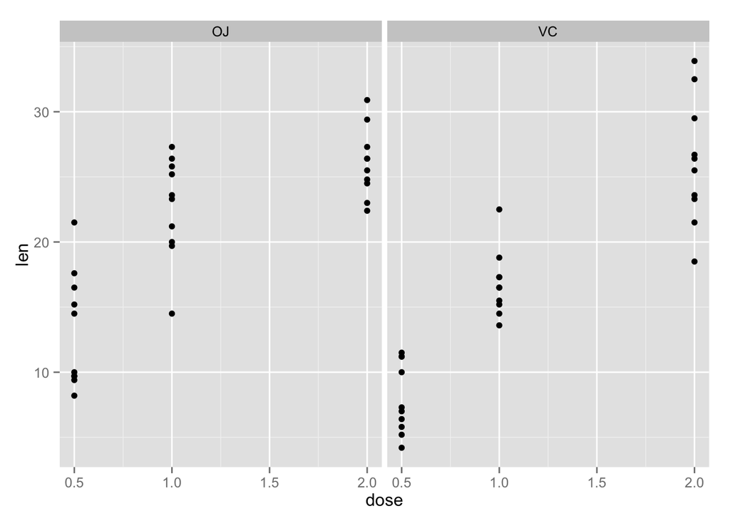

```r
qplot(x = dose, y = len, facets = ~ supp, data = ToothGrowth)
```

So now you see what’s going on.

Next, always make a histogram of the DV before making a linear model! This reveals the distribution and can be helpful in choosing your model type.

```
## stat_bin: binwidth defaulted to range/30. Use 'binwidth = x' to adjust this.
```

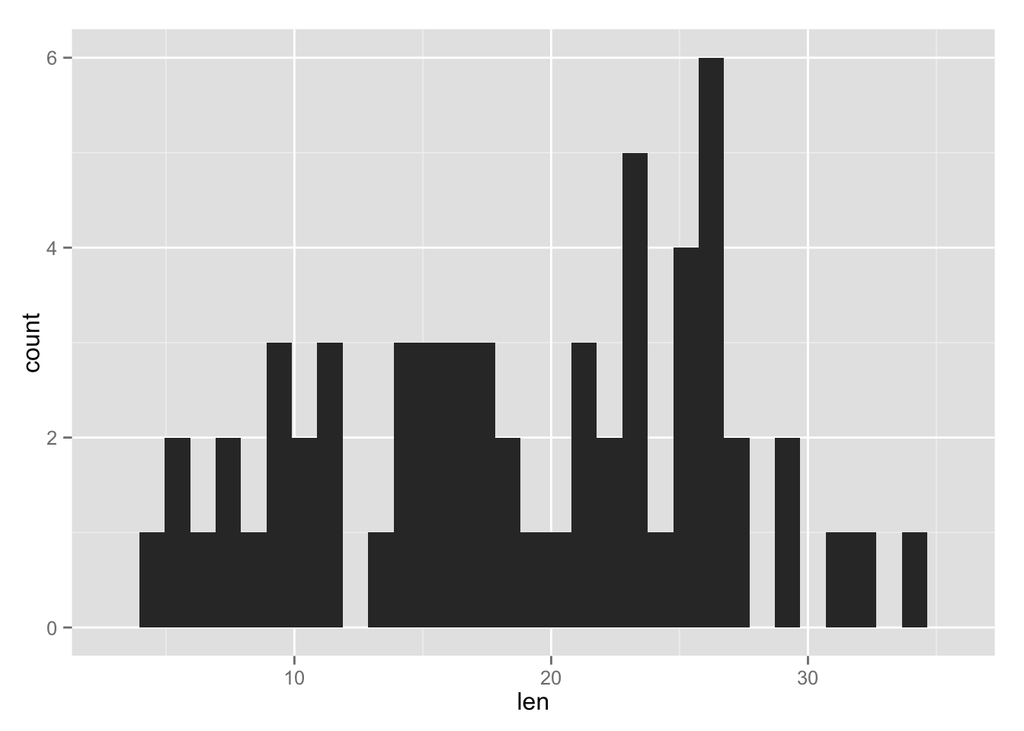

```r
qplot(len, data = ToothGrowth)
```

Now make a linear model of tooth lengths using `lm`. Try making one with main effects and interactions and another with just main effects. Make sure to assign them to variables so that you can get them later.

```r
r1 = lm(len ~ dose + supp, ToothGrowth); summary(r1)
```

```
##
## Call:
## lm(formula = len ~ dose + supp, data = ToothGrowth)
##
## Residuals:
##    Min     1Q Median     3Q    Max
## -6.600 -3.700  0.373  2.116  8.800
##
## Coefficients:
##             Estimate Std. Error t value Pr(>|t|)
## (Intercept)    9.273      1.282    7.23  1.3e-09 ***
## dose           9.764      0.877   11.14  6.3e-16 ***
## suppVC        -3.700      1.094   -3.38   0.0013 **
## ---
## Signif. codes:  0 '***' 0.001 '**' 0.01 '*' 0.05 '.' 0.1 ' ' 1
##
## Residual standard error: 4.24 on 57 degrees of freedom
## Multiple R-squared:  0.704,  Adjusted R-squared:  0.693
## F-statistic: 67.7 on 2 and 57 DF,  p-value: 8.72e-16
```

```r
r2 = lm(len ~ dose * supp, ToothGrowth); summary(r2)
```

```
##
## Call:
## lm(formula = len ~ dose * supp, data = ToothGrowth)
##
## Residuals:
##    Min     1Q Median     3Q    Max
##  -8.23  -2.85   0.05   2.29   7.94
##
## Coefficients:
##             Estimate Std. Error t value Pr(>|t|)
## (Intercept)    11.55       1.58    7.30  1.1e-09 ***
## dose            7.81       1.20    6.53  2.0e-08 ***
## suppVC         -8.26       2.24   -3.69  0.00051 ***
## dose:suppVC     3.90       1.69    2.31  0.02463 *
## ---
## Signif. codes:  0 '***' 0.001 '**' 0.01 '*' 0.05 '.' 0.1 ' ' 1
##
## Residual standard error: 4.08 on 56 degrees of freedom
## Multiple R-squared:  0.73,   Adjusted R-squared:  0.715
## F-statistic: 50.4 on 3 and 56 DF,  p-value: 6.52e-16
```

```r
anova(r1, r2)
```

```
## Analysis of Variance Table
##
## Model 1: len ~ dose + supp
## Model 2: len ~ dose * supp
##   Res.Df  RSS Df Sum of Sq    F Pr(>F)
## 1     57 1023
## 2     56  934  1      88.9 5.33  0.025 *
## ---
## Signif. codes:  0 '***' 0.001 '**' 0.01 '*' 0.05 '.' 0.1 ' ' 1
```

Looks like the interactive model is better (F(1,56) = 5.33, p = 0.025)! While higher doses of Vitamin C lead to longer tooth length, and OJ is more effective than VC, these main effects are qualified by a signif interaction between dose and supplement, with the differential effects of different supplements exagerrated at lower doses of supplement.

Now try taking out the intercept, using a -1 term in the formula. what does this do?

```r
r2b = lm(len ~ -1 + dose * supp, ToothGrowth); summary(r2b)
```

```
##
## Call:
## lm(formula = len ~ -1 + dose * supp, data = ToothGrowth)
##
## Residuals:
##    Min     1Q Median     3Q    Max
##  -8.23  -2.85   0.05   2.29   7.94
##
## Coefficients:
##             Estimate Std. Error t value Pr(>|t|)
## dose            7.81       1.20    6.53  2.0e-08 ***
## suppOJ         11.55       1.58    7.30  1.1e-09 ***
## suppVC          3.30       1.58    2.08    0.042 *
## dose:suppVC     3.90       1.69    2.31    0.025 *
## ---
## Signif. codes:  0 '***' 0.001 '**' 0.01 '*' 0.05 '.' 0.1 ' ' 1
##
## Residual standard error: 4.08 on 56 degrees of freedom
## Multiple R-squared:  0.962,  Adjusted R-squared:  0.959
## F-statistic:  356 on 4 and 56 DF,  p-value: <2e-16
```

Thought question: Take a moment to interpret the coefficients of the model. Q1 - What are the units? Maybe something like millimeters?

Q2 - How does the interaction relate to the plot? The significant interaction confirms that the effect of dose on tooth length differs for different supplements: it has a greater effect for the ascorbic acid (“VC”) supplement than for orange juice (“OJ”). Alternatively, we could say that the differential effects of OJ vs. VC on tooth length are exaggerated at lower doses.

Q3 - Should there be an interaction in the model? What does it mean? How important is it? Yes - see above for interpretation. The interactive model is a significantly better fit than the additive model.

Now make predictions from the model you like the best. What should happen with doses of 0, 1.5, 2.5, and 10 under both supplements?

HINT: use the `predict` function …

HINT 2: you will have to make a dataframe to do the prediction with, so use something like `data.frame(dose=...)`.

```r
new_data = data.frame(dose = rep(c(0, 1.5, 2.5, 10),2),
                      supp = c(rep("OJ", 4), rep("VC", 4)))

predict(r2, new_data)
```

```
##       1       2       3       4       5       6       7       8
##  11.550  23.267  31.079  89.664   3.295  20.869  32.584 120.452
```

Now plot the residuals from the original model. How do they look? HINT: `?resid`

```
## stat_bin: binwidth defaulted to range/30. Use 'binwidth = x' to adjust this.
```

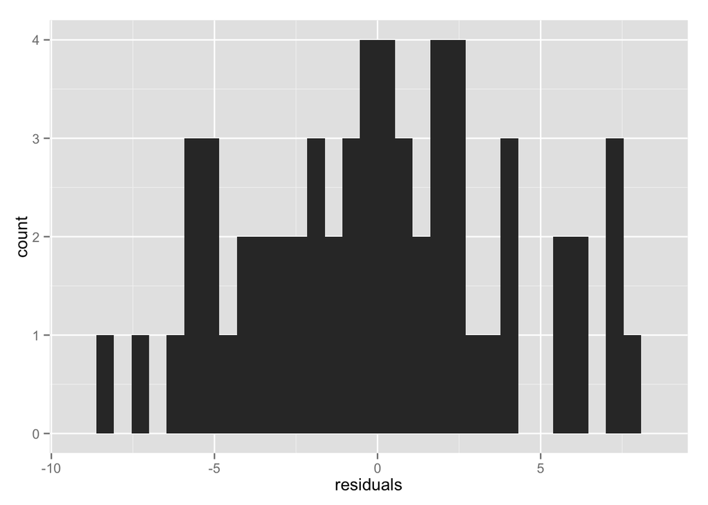

```r
residuals = as.numeric(resid(r2))
qplot(residuals)
```

I think they look pretty normal?

BONUS: test them for normality of distribution using a quantile-quantile plot.

HINT: `?qqplot` and `?qqnorm`

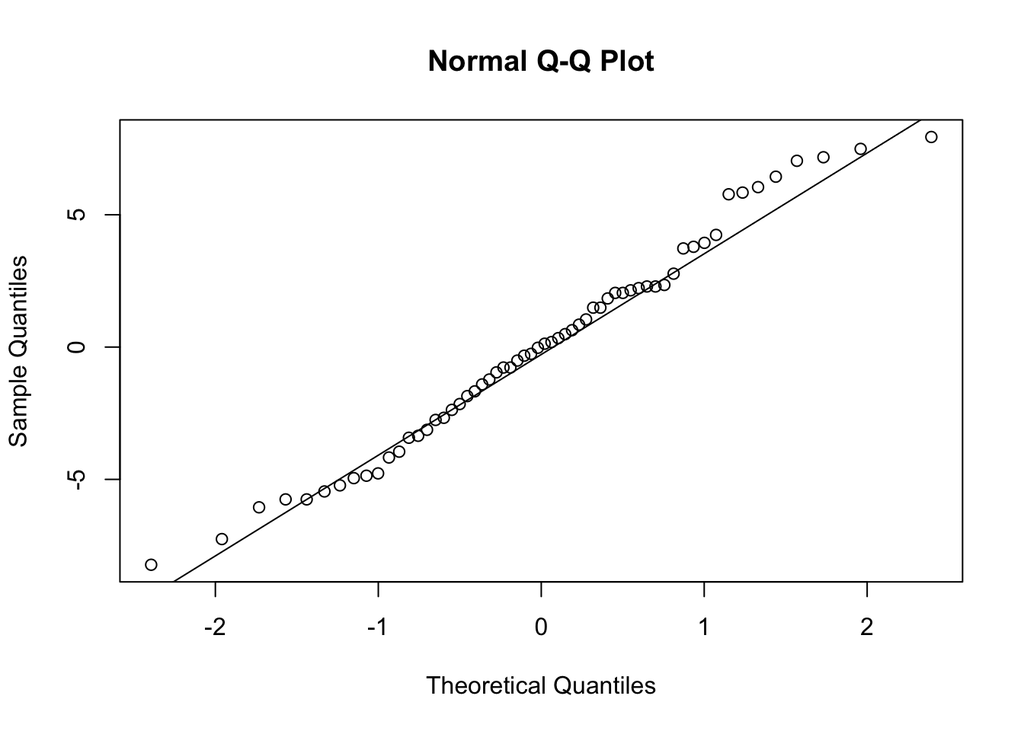

```r
qqnorm(residuals)
qqline(residuals)
```

Yes, the normal curve seems to be a good approximation of these residuals!

## 2B: Exploratory Linear Modeling

What the heck is going on? Load data from Frank, Vul, Saxe (2011, Infancy), a study in which we measured infants’ looking to hands in moving scenes. There were infants from 3 months all the way to about two years, and there were two movie conditions (`Faces_Medium`, in which kids played on a white background, and `Faces_Plus`, in which the backgrounds were more complex and the people in the videos were both kids and adults). Forgive our bad naming conventions.

Try to figure out what the most reasonable linear model of the data is.

```r
d <- read.csv("../data/FVS2011-hands.csv")

# check out data
glimpse(d)
```

```
## Observations: 232
## Variables:
## $ subid     (int) 2, 93, 29, 76, 48, 101, 67, 73, 69, 84, 66, 81, 28, ...
## $ age       (dbl) 3.156, 5.030, 5.852, 5.852, 6.082, 6.148, 6.542, 6.6...
## $ condition (fctr) Faces_Medium, Faces_Medium, Faces_Medium, Faces_Med...
## $ hand.look (dbl) 0.03188, 0.11885, 0.09212, 0.12961, 0.01379, 0.04385...
```

```r
head(d)
```

```
##   subid   age    condition hand.look
## 1     2 3.156 Faces_Medium   0.03188
## 2    93 5.030 Faces_Medium   0.11885
## 3    29 5.852 Faces_Medium   0.09212
## 4    76 5.852 Faces_Medium   0.12961
## 5    48 6.082 Faces_Medium   0.01379
## 6   101 6.148 Faces_Medium   0.04385
```

```r
count(d, subid) # looks like each kid saw both condtions?
```

```
## Source: local data frame [119 x 2]
##
##    subid n
## 1      1 2
## 2      2 2
## 3      3 2
## 4      4 2
## 5      5 1
## 6      6 2
## 7      7 2
## 8      8 2
## 9      9 2
## 10    10 2
## ..   ... .
```

```r
head(arrange(d, subid)) # yes, conditions was within-subjects --> use mixed models
```

```
##   subid    age    condition hand.look
## 1     1 12.033 Faces_Medium   0.05301
## 2     1 12.033   Faces_Plus   0.02380
## 3     2  3.156 Faces_Medium   0.03188
## 4     2  3.156   Faces_Plus   0.07803
## 5     3  9.534 Faces_Medium   0.03515
## 6     3  9.534   Faces_Plus   0.09588
```

```r
m1 = lmer(hand.look ~ age + condition + (1 | subid), d); summary(m1)
```

```
## Linear mixed model fit by REML ['lmerMod']
## Formula: hand.look ~ age + condition + (1 | subid)
##    Data: d
##
## REML criterion at convergence: -662.1
##
## Scaled residuals:
##    Min     1Q Median     3Q    Max
## -2.666 -0.623 -0.067  0.445  4.137
##
## Random effects:
##  Groups   Name        Variance Std.Dev.
##  subid    (Intercept) 0.000467 0.0216
##  Residual             0.002576 0.0508
## Number of obs: 232, groups:  subid, 119
##
## Fixed effects:
##                      Estimate Std. Error t value
## (Intercept)         -0.002126   0.012210   -0.17
## age                  0.005096   0.000895    5.69
## conditionFaces_Plus  0.020520   0.006677    3.07
##
## Correlation of Fixed Effects:
##             (Intr) age
## age         -0.908
## cndtnFcs_Pl -0.275  0.002
```

```r
m2 = lmer(hand.look ~ age * condition + (1 | subid), d); summary(m2)
```

```
## Linear mixed model fit by REML ['lmerMod']
## Formula: hand.look ~ age * condition + (1 | subid)
##    Data: d
##
## REML criterion at convergence: -657.9
##
## Scaled residuals:
##    Min     1Q Median     3Q    Max
## -3.282 -0.617 -0.061  0.464  3.994
##
## Random effects:
##  Groups   Name        Variance Std.Dev.
##  subid    (Intercept) 0.000549 0.0234
##  Residual             0.002431 0.0493
## Number of obs: 232, groups:  subid, 119
##
## Fixed effects:
##                         Estimate Std. Error t value
## (Intercept)              0.02301    0.01542    1.49
## age                      0.00306    0.00118    2.60
## conditionFaces_Plus     -0.02894    0.01965   -1.47
## age:conditionFaces_Plus  0.00400    0.00150    2.67
##
## Correlation of Fixed Effects:
##             (Intr) age    cndF_P
## age         -0.944
## cndtnFcs_Pl -0.646  0.611
## ag:cndtnF_P  0.610 -0.646 -0.944
```

```r
anova(m2, m1)
```

```
## refitting model(s) with ML (instead of REML)
```

```
## Data: d
## Models:
## m1: hand.look ~ age + condition + (1 | subid)
## m2: hand.look ~ age * condition + (1 | subid)
##    Df  AIC  BIC logLik deviance Chisq Chi Df Pr(>Chisq)
## m1  5 -682 -665    346     -692
## m2  6 -687 -666    349     -699  6.99      1     0.0082 **
## ---
## Signif. codes:  0 '***' 0.001 '**' 0.01 '*' 0.05 '.' 0.1 ' ' 1
```

Plot that model on the same plot as the data.

HINT: you can do this either using `predict` or (if you are feeling confident of your understanding of the models) using the built-in linear models in `ggplot`’s `geom_smooth`.

```
## geom_smooth: method="auto" and size of largest group is <1000, so using loess. Use 'method = x' to change the smoothing method.
```

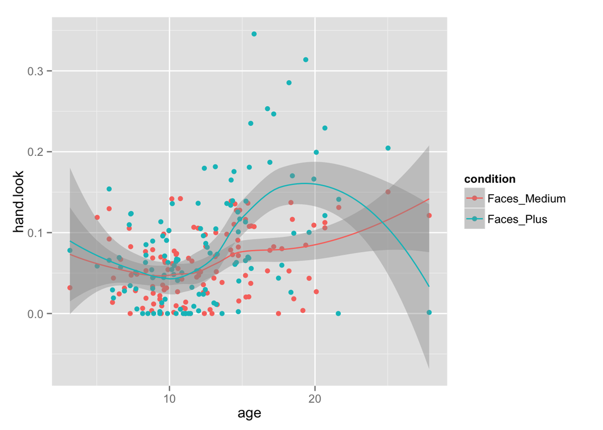

```r
qplot(x = age, y = hand.look, colour = condition, data = d) +
  geom_smooth()
```

```r
predictions = predict(m2, d)
# how to use predict to draw the lines?
```

What do you conclude from this pattern of data?